# Risk Factor Analysis

## Outcome Variable

**Outcome Variable:** stunted

## Predictor Variables

**Intervention Variable:** birthwt

**Adjustment Set:**

unadjusted

## Stratifying Variables

The analysis was stratified on these variable(s):

- agecat
- studyid

The following strata were considered:

- agecat: 12 months, studyid: ki0047075b-MAL-ED
- agecat: 12 months, studyid: ki1000108-CMC-V-BCS-2002
- agecat: 12 months, studyid: ki1000108-IRC
- agecat: 12 months, studyid: ki1000109-EE
- agecat: 12 months, studyid: ki1017093b-PROVIDE
- agecat: 12 months, studyid: ki1017093c-NIH-Crypto
- agecat: 12 months, studyid: ki1066203-TanzaniaChild2
- agecat: 12 months, studyid: ki1101329-Keneba
- agecat: 12 months, studyid: ki1126311-ZVITAMBO
- agecat: 12 months, studyid: ki1135781-COHORTS
- agecat: 18 months, studyid: ki0047075b-MAL-ED
- agecat: 18 months, studyid: ki1000108-CMC-V-BCS-2002
- agecat: 18 months, studyid: ki1000108-IRC
- agecat: 18 months, studyid: ki1000109-EE
- agecat: 18 months, studyid: ki1017093b-PROVIDE
- agecat: 18 months, studyid: ki1017093c-NIH-Crypto
- agecat: 18 months, studyid: ki1066203-TanzaniaChild2
- agecat: 18 months, studyid: ki1101329-Keneba
- agecat: 18 months, studyid: ki1126311-ZVITAMBO
- agecat: 18 months, studyid: ki1135781-COHORTS
- agecat: 24 months, studyid: ki0047075b-MAL-ED
- agecat: 24 months, studyid: ki1000108-CMC-V-BCS-2002
- agecat: 24 months, studyid: ki1000108-IRC
- agecat: 24 months, studyid: ki1017093b-PROVIDE
- agecat: 24 months, studyid: ki1017093c-NIH-Crypto
- agecat: 24 months, studyid: ki1066203-TanzaniaChild2
- agecat: 24 months, studyid: ki1101329-Keneba
- agecat: 24 months, studyid: ki1126311-ZVITAMBO
- agecat: 24 months, studyid: ki1135781-COHORTS
- agecat: 3 months, studyid: ki0047075b-MAL-ED
- agecat: 3 months, studyid: ki1000108-CMC-V-BCS-2002
- agecat: 3 months, studyid: ki1000108-IRC
- agecat: 3 months, studyid: ki1000109-EE
- agecat: 3 months, studyid: ki1017093b-PROVIDE
- agecat: 3 months, studyid: ki1017093c-NIH-Crypto
- agecat: 3 months, studyid: ki1066203-TanzaniaChild2
- agecat: 3 months, studyid: ki1101329-Keneba
- agecat: 3 months, studyid: ki1126311-ZVITAMBO
- agecat: 3 months, studyid: ki1135781-COHORTS
- agecat: 6 months, studyid: ki0047075b-MAL-ED
- agecat: 6 months, studyid: ki1000108-CMC-V-BCS-2002
- agecat: 6 months, studyid: ki1000108-IRC
- agecat: 6 months, studyid: ki1000109-EE
- agecat: 6 months, studyid: ki1017093b-PROVIDE
- agecat: 6 months, studyid: ki1017093c-NIH-Crypto
- agecat: 6 months, studyid: ki1066203-TanzaniaChild2
- agecat: 6 months, studyid: ki1101329-Keneba
- agecat: 6 months, studyid: ki1126311-ZVITAMBO
- agecat: 6 months, studyid: ki1135781-COHORTS
- agecat: 9 months, studyid: ki0047075b-MAL-ED
- agecat: 9 months, studyid: ki1000108-CMC-V-BCS-2002
- agecat: 9 months, studyid: ki1000108-IRC
- agecat: 9 months, studyid: ki1000109-EE
- agecat: 9 months, studyid: ki1017093b-PROVIDE
- agecat: 9 months, studyid: ki1017093c-NIH-Crypto
- agecat: 9 months, studyid: ki1066203-TanzaniaChild2
- agecat: 9 months, studyid: ki1101329-Keneba
- agecat: 9 months, studyid: ki1126311-ZVITAMBO
- agecat: 9 months, studyid: ki1135781-COHORTS
- agecat: Birth, studyid: ki0047075b-MAL-ED
- agecat: Birth, studyid: ki1000108-CMC-V-BCS-2002
- agecat: Birth, studyid: ki1000108-IRC
- agecat: Birth, studyid: ki1000109-EE
- agecat: Birth, studyid: ki1017093c-NIH-Crypto
- agecat: Birth, studyid: ki1101329-Keneba
- agecat: Birth, studyid: ki1126311-ZVITAMBO
- agecat: Birth, studyid: ki1135781-COHORTS

### Dropped Strata

Some strata were dropped due to rare outcomes:

- agecat: Birth, studyid: ki1000108-CMC-V-BCS-2002
- agecat: Birth, studyid: ki1000108-IRC
- agecat: Birth, studyid: ki1000109-EE
- agecat: Birth, studyid: ki1017093c-NIH-Crypto
- agecat: Birth, studyid: ki1101329-Keneba
- agecat: 3 months, studyid: ki1000108-IRC
- agecat: 3 months, studyid: ki1017093b-PROVIDE
- agecat: 3 months, studyid: ki1017093c-NIH-Crypto
- agecat: 3 months, studyid: ki1066203-TanzaniaChild2
- agecat: 6 months, studyid: ki1017093b-PROVIDE
- agecat: 9 months, studyid: ki1017093b-PROVIDE
- agecat: 12 months, studyid: ki1017093b-PROVIDE
- agecat: 12 months, studyid: ki1017093c-NIH-Crypto
- agecat: 18 months, studyid: ki1017093b-PROVIDE
- agecat: 24 months, studyid: ki1017093b-PROVIDE
- agecat: 24 months, studyid: ki1017093c-NIH-Crypto
- agecat: 24 months, studyid: ki1066203-TanzaniaChild2

## Methods Detail

We’re interested in the causal parameters $E[Y_a]$ for all values of $a \in \mathcal{A}$. These parameters represent the mean outcome if, possibly contrary to fact, we intervened to set all units to have $A=a$. Under the randomization and positivity assumptions, these are identified by the statistical parameters $\psi_a=E_W[E_{Y|A,W}(Y|A=a,W)]$. In addition, we’re interested in the mean of $Y$, $E[Y]$ under no intervention (the observed mean). We will estimate these parameters by using SuperLearner to fit the relevant likelihood factors – $E_{Y|A,W}(Y|A=a,W)$ and $p(A=a|W)$, and then updating our likelihood fit using a joint TMLE.

For unadjusted analyses ($W=\{\}$), initial likelihoods were estimated using Lrnr_glm to estimate the simple $E(Y|A)$ and Lrnr_mean to estimate $p(A)$. For adjusted analyses, a small library containing Lrnr_glmnet, Lrnr_xgboost, and Lrnr_mean was used.

Having estimated these parameters, we will then use the delta method to estimate relative risks and attributable risks relative to a prespecified baseline level of $A$.

# Results Detail

## Results Plots

[figure not shown]

[figure not shown]

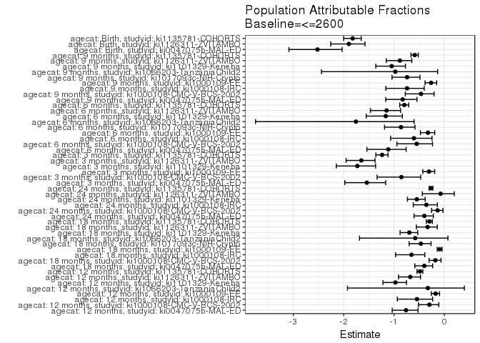

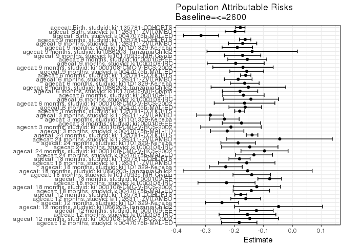

## Data Summary

| agecat | studyid | A | n | nA | nAY0 | nAY1 |
| --- | --- | --- | --- | --- | --- | --- |
| Birth | ki0047075b-MAL-ED | <=2600 | 1486 | 261 | 146 | 115 |
| Birth | ki0047075b-MAL-ED | (2600-2970] | 1486 | 328 | 292 | 36 |
| Birth | ki0047075b-MAL-ED | (2970-3302.75] | 1486 | 481 | 453 | 28 |
| Birth | ki0047075b-MAL-ED | >3302.75 | 1486 | 416 | 409 | 7 |
| Birth | ki1000108-CMC-V-BCS-2002 | <=2600 | 90 | 28 | 19 | 9 |
| Birth | ki1000108-CMC-V-BCS-2002 | (2600-2970] | 90 | 23 | 19 | 4 |
| Birth | ki1000108-CMC-V-BCS-2002 | (2970-3302.75] | 90 | 28 | 26 | 2 |
| Birth | ki1000108-CMC-V-BCS-2002 | >3302.75 | 90 | 11 | 10 | 1 |
| Birth | ki1000108-IRC | <=2600 | 383 | 98 | 73 | 25 |
| Birth | ki1000108-IRC | (2600-2970] | 383 | 114 | 107 | 7 |
| Birth | ki1000108-IRC | (2970-3302.75] | 383 | 113 | 102 | 11 |
| Birth | ki1000108-IRC | >3302.75 | 383 | 58 | 57 | 1 |
| Birth | ki1000109-EE | <=2600 | 2 | 1 | 0 | 1 |
| Birth | ki1000109-EE | (2600-2970] | 2 | 1 | 1 | 0 |
| Birth | ki1000109-EE | (2970-3302.75] | 2 | 0 | 0 | 0 |
| Birth | ki1000109-EE | >3302.75 | 2 | 0 | 0 | 0 |
| Birth | ki1017093b-PROVIDE | <=2600 | 0 | 0 | 0 | 0 |
| Birth | ki1017093b-PROVIDE | (2600-2970] | 0 | 0 | 0 | 0 |
| Birth | ki1017093b-PROVIDE | (2970-3302.75] | 0 | 0 | 0 | 0 |
| Birth | ki1017093b-PROVIDE | >3302.75 | 0 | 0 | 0 | 0 |
| Birth | ki1017093c-NIH-Crypto | <=2600 | 27 | 10 | 6 | 4 |
| Birth | ki1017093c-NIH-Crypto | (2600-2970] | 27 | 9 | 8 | 1 |
| Birth | ki1017093c-NIH-Crypto | (2970-3302.75] | 27 | 8 | 8 | 0 |
| Birth | ki1017093c-NIH-Crypto | >3302.75 | 27 | 0 | 0 | 0 |
| Birth | ki1066203-TanzaniaChild2 | <=2600 | 0 | 0 | 0 | 0 |
| Birth | ki1066203-TanzaniaChild2 | (2600-2970] | 0 | 0 | 0 | 0 |
| Birth | ki1066203-TanzaniaChild2 | (2970-3302.75] | 0 | 0 | 0 | 0 |
| Birth | ki1066203-TanzaniaChild2 | >3302.75 | 0 | 0 | 0 | 0 |
| Birth | ki1101329-Keneba | <=2600 | 1527 | 293 | 245 | 48 |
| Birth | ki1101329-Keneba | (2600-2970] | 1527 | 491 | 463 | 28 |

[output cut: 250 more lines]

## Results Table

### Parameter: TSM

| agecat | studyid | intervention_level | baseline_level | estimate | ci_lower | ci_upper |
| --- | --- | --- | --- | --- | --- | --- |
| Birth | ki0047075b-MAL-ED | <=2600 | NA | 0.4406130 | 0.3803628 | 0.5008633 |
| Birth | ki0047075b-MAL-ED | (2600-2970] | NA | 0.1097561 | 0.0759164 | 0.1435958 |
| Birth | ki0047075b-MAL-ED | (2970-3302.75] | NA | 0.0582121 | 0.0372803 | 0.0791438 |
| Birth | ki0047075b-MAL-ED | >3302.75 | NA | 0.0168269 | 0.0044628 | 0.0291911 |
| Birth | ki1126311-ZVITAMBO | <=2600 | NA | 0.3024251 | 0.2684190 | 0.3364312 |
| Birth | ki1126311-ZVITAMBO | (2600-2970] | NA | 0.0899358 | 0.0715856 | 0.1082859 |
| Birth | ki1126311-ZVITAMBO | (2970-3302.75] | NA | 0.0453686 | 0.0328267 | 0.0579105 |
| Birth | ki1126311-ZVITAMBO | >3302.75 | NA | 0.0211640 | 0.0109027 | 0.0314254 |
| Birth | ki1135781-COHORTS | <=2600 | NA | 0.2782495 | 0.2623758 | 0.2941232 |
| Birth | ki1135781-COHORTS | (2600-2970] | NA | 0.0363964 | 0.0294283 | 0.0433645 |
| Birth | ki1135781-COHORTS | (2970-3302.75] | NA | 0.0104384 | 0.0067225 | 0.0141543 |
| Birth | ki1135781-COHORTS | >3302.75 | NA | 0.0045662 | 0.0009207 | 0.0082117 |
| 3 months | ki0047075b-MAL-ED | <=2600 | NA | 0.3713235 | 0.3138870 | 0.4287600 |
| 3 months | ki0047075b-MAL-ED | (2600-2970] | NA | 0.1751412 | 0.1355349 | 0.2147476 |
| 3 months | ki0047075b-MAL-ED | (2970-3302.75] | NA | 0.1038462 | 0.0776180 | 0.1300743 |
| 3 months | ki0047075b-MAL-ED | >3302.75 | NA | 0.0405983 | 0.0227123 | 0.0584843 |
| 3 months | ki1000108-CMC-V-BCS-2002 | <=2600 | NA | 0.4606742 | 0.3569747 | 0.5643736 |
| 3 months | ki1000108-CMC-V-BCS-2002 | (2600-2970] | NA | 0.2650602 | 0.1699761 | 0.3601443 |
| 3 months | ki1000108-CMC-V-BCS-2002 | (2970-3302.75] | NA | 0.1666667 | 0.1015042 | 0.2318291 |
| 3 months | ki1000108-CMC-V-BCS-2002 | >3302.75 | NA | 0.0937500 | 0.0222397 | 0.1652603 |
| 3 months | ki1000109-EE | <=2600 | NA | 0.7528090 | 0.6893526 | 0.8162653 |
| 3 months | ki1000109-EE | (2600-2970] | NA | 0.5312500 | 0.4312935 | 0.6312065 |
| 3 months | ki1000109-EE | (2970-3302.75] | NA | 0.3913043 | 0.2759964 | 0.5066123 |
| 3 months | ki1000109-EE | >3302.75 | NA | 0.1515152 | 0.0290198 | 0.2740105 |
| 3 months | ki1101329-Keneba | <=2600 | NA | 0.3703704 | 0.3198372 | 0.4209035 |
| 3 months | ki1101329-Keneba | (2600-2970] | NA | 0.1209386 | 0.0937801 | 0.1480972 |
| 3 months | ki1101329-Keneba | (2970-3302.75] | NA | 0.0681004 | 0.0471924 | 0.0890083 |
| 3 months | ki1101329-Keneba | >3302.75 | NA | 0.0244648 | 0.0077159 | 0.0412138 |
| 3 months | ki1126311-ZVITAMBO | <=2600 | NA | 0.4555809 | 0.4089835 | 0.5021782 |
| 3 months | ki1126311-ZVITAMBO | (2600-2970] | NA | 0.1788079 | 0.1482417 | 0.2093741 |

[output cut: 170 more lines]

### Parameter: E(Y)

| agecat | studyid | intervention_level | baseline_level | estimate | ci_lower | ci_upper |
| --- | --- | --- | --- | --- | --- | --- |
| Birth | ki0047075b-MAL-ED | NA | NA | 0.1251682 | 0.1175788 | 0.1327577 |
| Birth | ki1126311-ZVITAMBO | NA | NA | 0.1043781 | 0.1009392 | 0.1078169 |
| Birth | ki1135781-COHORTS | NA | NA | 0.0986534 | 0.0963111 | 0.1009956 |
| 3 months | ki0047075b-MAL-ED | NA | NA | 0.1462206 | 0.1407565 | 0.1516846 |
| 3 months | ki1000108-CMC-V-BCS-2002 | NA | NA | 0.2486188 | 0.2348965 | 0.2623411 |
| 3 months | ki1000109-EE | NA | NA | 0.5771277 | 0.5575585 | 0.5966969 |
| 3 months | ki1101329-Keneba | NA | NA | 0.1357542 | 0.1301645 | 0.1413439 |
| 3 months | ki1126311-ZVITAMBO | NA | NA | 0.1719717 | 0.1658797 | 0.1780637 |
| 3 months | ki1135781-COHORTS | NA | NA | 0.1470982 | 0.1446482 | 0.1495483 |
| 6 months | ki0047075b-MAL-ED | NA | NA | 0.1462939 | 0.1420277 | 0.1505601 |
| 6 months | ki1000108-CMC-V-BCS-2002 | NA | NA | 0.3008130 | 0.2903482 | 0.3112779 |
| 6 months | ki1000108-IRC | NA | NA | 0.2369077 | 0.2277183 | 0.2460972 |
| 6 months | ki1000109-EE | NA | NA | 0.5188172 | 0.5001087 | 0.5375257 |
| 6 months | ki1017093c-NIH-Crypto | NA | NA | 0.2097902 | 0.1998632 | 0.2197172 |
| 6 months | ki1066203-TanzaniaChild2 | NA | NA | 0.0863454 | 0.0818545 | 0.0908362 |
| 6 months | ki1101329-Keneba | NA | NA | 0.1414378 | 0.1371761 | 0.1456994 |
| 6 months | ki1126311-ZVITAMBO | NA | NA | 0.1628362 | 0.1585822 | 0.1670902 |
| 6 months | ki1135781-COHORTS | NA | NA | 0.2027521 | 0.2004804 | 0.2050238 |
| 9 months | ki0047075b-MAL-ED | NA | NA | 0.1901882 | 0.1858347 | 0.1945416 |
| 9 months | ki1000108-CMC-V-BCS-2002 | NA | NA | 0.3688525 | 0.3582108 | 0.3794941 |
| 9 months | ki1000108-IRC | NA | NA | 0.2643392 | 0.2522687 | 0.2764096 |
| 9 months | ki1000109-EE | NA | NA | 0.5928962 | 0.5758499 | 0.6099424 |
| 9 months | ki1017093c-NIH-Crypto | NA | NA | 0.2322946 | 0.2226148 | 0.2419744 |
| 9 months | ki1066203-TanzaniaChild2 | NA | NA | 0.1425234 | 0.1361274 | 0.1489193 |
| 9 months | ki1101329-Keneba | NA | NA | 0.1818182 | 0.1764571 | 0.1871792 |
| 9 months | ki1126311-ZVITAMBO | NA | NA | 0.1943878 | 0.1902526 | 0.1985229 |
| 9 months | ki1135781-COHORTS | NA | NA | 0.2770984 | 0.2746103 | 0.2795866 |
| 12 months | ki0047075b-MAL-ED | NA | NA | 0.2411444 | 0.2364161 | 0.2458727 |
| 12 months | ki1000108-CMC-V-BCS-2002 | NA | NA | 0.4972826 | 0.4851043 | 0.5094609 |
| 12 months | ki1000108-IRC | NA | NA | 0.2850000 | 0.2729592 | 0.2970408 |
| 12 months | ki1000109-EE | NA | NA | 0.7142857 | 0.6992621 | 0.7293093 |
| 12 months | ki1066203-TanzaniaChild2 | NA | NA | 0.1448864 | 0.1384111 | 0.1513616 |
| 12 months | ki1101329-Keneba | NA | NA | 0.2501556 | 0.2436103 | 0.2567008 |
| 12 months | ki1126311-ZVITAMBO | NA | NA | 0.2377869 | 0.2332232 | 0.2423507 |
| 12 months | ki1135781-COHORTS | NA | NA | 0.3673865 | 0.3645811 | 0.3701919 |
| 18 months | ki0047075b-MAL-ED | NA | NA | 0.3561742 | 0.3514564 | 0.3608919 |
| 18 months | ki1000108-CMC-V-BCS-2002 | NA | NA | 0.6883469 | 0.6789184 | 0.6977753 |
| 18 months | ki1000108-IRC | NA | NA | 0.3483709 | 0.3330914 | 0.3636504 |
| 18 months | ki1000109-EE | NA | NA | 0.8485714 | 0.8405498 | 0.8565931 |
| 18 months | ki1017093c-NIH-Crypto | NA | NA | 0.3012618 | 0.2922480 | 0.3102756 |
| 18 months | ki1066203-TanzaniaChild2 | NA | NA | 0.2666667 | 0.2525159 | 0.2808174 |
| 18 months | ki1101329-Keneba | NA | NA | 0.3308458 | 0.3238813 | 0.3378102 |
| 18 months | ki1126311-ZVITAMBO | NA | NA | 0.4740566 | 0.4637675 | 0.4843457 |
| 18 months | ki1135781-COHORTS | NA | NA | 0.6145191 | 0.6108192 | 0.6182189 |
| 24 months | ki0047075b-MAL-ED | NA | NA | 0.3335804 | 0.3288867 | 0.3382741 |
| 24 months | ki1000108-CMC-V-BCS-2002 | NA | NA | 0.7150538 | 0.7068991 | 0.7232085 |
| 24 months | ki1000108-IRC | NA | NA | 0.4119107 | 0.3984595 | 0.4253619 |
| 24 months | ki1101329-Keneba | NA | NA | 0.3422160 | 0.3357729 | 0.3486590 |
| 24 months | ki1126311-ZVITAMBO | NA | NA | 0.5862069 | 0.5751503 | 0.5972635 |
| 24 months | ki1135781-COHORTS | NA | NA | 0.5251485 | 0.5228247 | 0.5274724 |

### Parameter: RR

| agecat | studyid | intervention_level | baseline_level | estimate | ci_lower | ci_upper |
| --- | --- | --- | --- | --- | --- | --- |
| Birth | ki0047075b-MAL-ED | (2600-2970] | <=2600 | 0.2490986 | 0.1777839 | 0.3490198 |
| Birth | ki0047075b-MAL-ED | (2970-3302.75] | <=2600 | 0.1321161 | 0.0899255 | 0.1941014 |
| Birth | ki0047075b-MAL-ED | >3302.75 | <=2600 | 0.0381898 | 0.0180865 | 0.0806379 |
| Birth | ki1126311-ZVITAMBO | (2600-2970] | <=2600 | 0.2973819 | 0.2355794 | 0.3753978 |
| Birth | ki1126311-ZVITAMBO | (2970-3302.75] | <=2600 | 0.1500161 | 0.1113083 | 0.2021845 |
| Birth | ki1126311-ZVITAMBO | >3302.75 | <=2600 | 0.0699810 | 0.0425427 | 0.1151161 |
| Birth | ki1135781-COHORTS | (2600-2970] | <=2600 | 0.1308049 | 0.1071186 | 0.1597287 |
| Birth | ki1135781-COHORTS | (2970-3302.75] | <=2600 | 0.0375146 | 0.0261593 | 0.0537991 |
| Birth | ki1135781-COHORTS | >3302.75 | <=2600 | 0.0164105 | 0.0073708 | 0.0365368 |
| 3 months | ki0047075b-MAL-ED | (2600-2970] | <=2600 | 0.4716675 | 0.3586310 | 0.6203318 |
| 3 months | ki0047075b-MAL-ED | (2970-3302.75] | <=2600 | 0.2796649 | 0.2079760 | 0.3760648 |
| 3 months | ki0047075b-MAL-ED | >3302.75 | <=2600 | 0.1093340 | 0.0685444 | 0.1743969 |
| 3 months | ki1000108-CMC-V-BCS-2002 | (2600-2970] | <=2600 | 0.5753747 | 0.3767255 | 0.8787726 |
| 3 months | ki1000108-CMC-V-BCS-2002 | (2970-3302.75] | <=2600 | 0.3617886 | 0.2304224 | 0.5680481 |
| 3 months | ki1000108-CMC-V-BCS-2002 | >3302.75 | <=2600 | 0.2035061 | 0.0918721 | 0.4507867 |
| 3 months | ki1000109-EE | (2600-2970] | <=2600 | 0.7056903 | 0.5742153 | 0.8672685 |
| 3 months | ki1000109-EE | (2970-3302.75] | <=2600 | 0.5197923 | 0.3825787 | 0.7062183 |
| 3 months | ki1000109-EE | >3302.75 | <=2600 | 0.2012664 | 0.0892800 | 0.4537203 |
| 3 months | ki1101329-Keneba | (2600-2970] | <=2600 | 0.3265343 | 0.2510798 | 0.4246644 |
| 3 months | ki1101329-Keneba | (2970-3302.75] | <=2600 | 0.1838710 | 0.1314025 | 0.2572898 |
| 3 months | ki1101329-Keneba | >3302.75 | <=2600 | 0.0660550 | 0.0328651 | 0.1327631 |
| 3 months | ki1126311-ZVITAMBO | (2600-2970] | <=2600 | 0.3924834 | 0.3215932 | 0.4790003 |
| 3 months | ki1126311-ZVITAMBO | (2970-3302.75] | <=2600 | 0.1836950 | 0.1409523 | 0.2393992 |
| 3 months | ki1126311-ZVITAMBO | >3302.75 | <=2600 | 0.0939494 | 0.0616358 | 0.1432040 |
| 3 months | ki1135781-COHORTS | (2600-2970] | <=2600 | 0.3072640 | 0.2715201 | 0.3477133 |
| 3 months | ki1135781-COHORTS | (2970-3302.75] | <=2600 | 0.1615512 | 0.1369790 | 0.1905313 |
| 3 months | ki1135781-COHORTS | >3302.75 | <=2600 | 0.0753317 | 0.0530094 | 0.1070539 |
| 6 months | ki0047075b-MAL-ED | (2600-2970] | <=2600 | 0.5570102 | 0.4136045 | 0.7501377 |
| 6 months | ki0047075b-MAL-ED | (2970-3302.75] | <=2600 | 0.4091923 | 0.3051457 | 0.5487160 |
| 6 months | ki0047075b-MAL-ED | >3302.75 | <=2600 | 0.1736681 | 0.1130450 | 0.2668018 |

[output cut: 120 more lines]

### Parameter: PAR

| agecat | studyid | intervention_level | baseline_level | estimate | ci_lower | ci_upper |
| --- | --- | --- | --- | --- | --- | --- |
| Birth | ki0047075b-MAL-ED | <=2600 | NA | -0.3154448 | -0.3761712 | -0.2547184 |
| Birth | ki1126311-ZVITAMBO | <=2600 | NA | -0.1980470 | -0.2322265 | -0.1638675 |
| Birth | ki1135781-COHORTS | <=2600 | NA | -0.1795961 | -0.1956417 | -0.1635506 |
| 3 months | ki0047075b-MAL-ED | <=2600 | NA | -0.2251030 | -0.2827988 | -0.1674071 |
| 3 months | ki1000108-CMC-V-BCS-2002 | <=2600 | NA | -0.2120554 | -0.3166588 | -0.1074520 |
| 3 months | ki1000109-EE | <=2600 | NA | -0.1756813 | -0.2420866 | -0.1092760 |
| 3 months | ki1101329-Keneba | <=2600 | NA | -0.2346162 | -0.2854576 | -0.1837748 |
| 3 months | ki1126311-ZVITAMBO | <=2600 | NA | -0.2836092 | -0.3306030 | -0.2366153 |
| 3 months | ki1135781-COHORTS | <=2600 | NA | -0.1818491 | -0.1989407 | -0.1647576 |
| 6 months | ki0047075b-MAL-ED | <=2600 | NA | -0.1628664 | -0.2190070 | -0.1067259 |
| 6 months | ki1000108-CMC-V-BCS-2002 | <=2600 | NA | -0.1650961 | -0.2699843 | -0.0602079 |
| 6 months | ki1000108-IRC | <=2600 | NA | -0.1430923 | -0.2387874 | -0.0473972 |
| 6 months | ki1000109-EE | <=2600 | NA | -0.1690441 | -0.2406712 | -0.0974169 |
| 6 months | ki1017093c-NIH-Crypto | <=2600 | NA | -0.1806480 | -0.2418533 | -0.1194427 |
| 6 months | ki1066203-TanzaniaChild2 | <=2600 | NA | -0.1517499 | -0.2807674 | -0.0227323 |
| 6 months | ki1101329-Keneba | <=2600 | NA | -0.1646229 | -0.2145424 | -0.1147033 |
| 6 months | ki1126311-ZVITAMBO | <=2600 | NA | -0.1870333 | -0.2349981 | -0.1390684 |
| 6 months | ki1135781-COHORTS | <=2600 | NA | -0.1610784 | -0.1790152 | -0.1431417 |
| 9 months | ki0047075b-MAL-ED | <=2600 | NA | -0.1574681 | -0.2159865 | -0.0989497 |
| 9 months | ki1000108-CMC-V-BCS-2002 | <=2600 | NA | -0.1704734 | -0.2747158 | -0.0662309 |
| 9 months | ki1000108-IRC | <=2600 | NA | -0.1956608 | -0.2942090 | -0.0971127 |
| 9 months | ki1000109-EE | <=2600 | NA | -0.1556418 | -0.2229520 | -0.0883317 |
| 9 months | ki1017093c-NIH-Crypto | <=2600 | NA | -0.1718720 | -0.2347504 | -0.1089937 |
| 9 months | ki1066203-TanzaniaChild2 | <=2600 | NA | -0.1387266 | -0.2948188 | 0.0173655 |
| 9 months | ki1101329-Keneba | <=2600 | NA | -0.1901330 | -0.2427282 | -0.1375378 |
| 9 months | ki1126311-ZVITAMBO | <=2600 | NA | -0.1716600 | -0.2204745 | -0.1228454 |
| 9 months | ki1135781-COHORTS | <=2600 | NA | -0.1629500 | -0.1826573 | -0.1432428 |
| 12 months | ki0047075b-MAL-ED | <=2600 | NA | -0.1834588 | -0.2446896 | -0.1222280 |
| 12 months | ki1000108-CMC-V-BCS-2002 | <=2600 | NA | -0.1471618 | -0.2469373 | -0.0473864 |
| 12 months | ki1000108-IRC | <=2600 | NA | -0.1550000 | -0.2531532 | -0.0568468 |
| 12 months | ki1000109-EE | <=2600 | NA | -0.1240376 | -0.1819358 | -0.0661395 |
| 12 months | ki1066203-TanzaniaChild2 | <=2600 | NA | -0.0474213 | -0.1992647 | 0.1044220 |
| 12 months | ki1101329-Keneba | <=2600 | NA | -0.2431330 | -0.3002904 | -0.1859756 |
| 12 months | ki1126311-ZVITAMBO | <=2600 | NA | -0.1610735 | -0.2125176 | -0.1096293 |
| 12 months | ki1135781-COHORTS | <=2600 | NA | -0.1779456 | -0.1988125 | -0.1570788 |
| 18 months | ki0047075b-MAL-ED | <=2600 | NA | -0.1417850 | -0.2045930 | -0.0789770 |
| 18 months | ki1000108-CMC-V-BCS-2002 | <=2600 | NA | -0.1227642 | -0.2042879 | -0.0412406 |
| 18 months | ki1000108-IRC | <=2600 | NA | -0.2273866 | -0.3260539 | -0.1287194 |
| 18 months | ki1000109-EE | <=2600 | NA | -0.0782578 | -0.1189691 | -0.0375466 |
| 18 months | ki1017093c-NIH-Crypto | <=2600 | NA | -0.1402966 | -0.2050141 | -0.0755791 |
| 18 months | ki1066203-TanzaniaChild2 | <=2600 | NA | -0.1543860 | -0.3772753 | 0.0685034 |
| 18 months | ki1101329-Keneba | <=2600 | NA | -0.2299650 | -0.2869473 | -0.1729828 |
| 18 months | ki1126311-ZVITAMBO | <=2600 | NA | -0.1575223 | -0.2551806 | -0.0598641 |
| 18 months | ki1135781-COHORTS | <=2600 | NA | -0.1824895 | -0.2191248 | -0.1458541 |
| 24 months | ki0047075b-MAL-ED | <=2600 | NA | -0.1325213 | -0.1963623 | -0.0686803 |
| 24 months | ki1000108-CMC-V-BCS-2002 | <=2600 | NA | -0.0960573 | -0.1774426 | -0.0146721 |
| 24 months | ki1000108-IRC | <=2600 | NA | -0.1469129 | -0.2443246 | -0.0495011 |
| 24 months | ki1101329-Keneba | <=2600 | NA | -0.1871958 | -0.2468826 | -0.1275089 |
| 24 months | ki1126311-ZVITAMBO | <=2600 | NA | -0.0434227 | -0.2266958 | 0.1398504 |
| 24 months | ki1135781-COHORTS | <=2600 | NA | -0.1390547 | -0.1590846 | -0.1190248 |

### Parameter: PAF

| agecat | studyid | intervention_level | baseline_level | estimate | ci_lower | ci_upper |
| --- | --- | --- | --- | --- | --- | --- |
| Birth | ki0047075b-MAL-ED | <=2600 | NA | -2.5201664 | -3.0881417 | -2.0311014 |
| Birth | ki1126311-ZVITAMBO | <=2600 | NA | -1.8974005 | -2.2575837 | -1.5770420 |
| Birth | ki1135781-COHORTS | <=2600 | NA | -1.8204765 | -2.0002560 | -1.6514697 |
| 3 months | ki0047075b-MAL-ED | <=2600 | NA | -1.5394753 | -1.9775113 | -1.1658809 |
| 3 months | ki1000108-CMC-V-BCS-2002 | <=2600 | NA | -0.8529338 | -1.3362375 | -0.4696125 |
| 3 months | ki1000109-EE | <=2600 | NA | -0.3044064 | -0.4284718 | -0.1911163 |
| 3 months | ki1101329-Keneba | <=2600 | NA | -1.7282426 | -2.1461356 | -1.3658573 |
| 3 months | ki1126311-ZVITAMBO | <=2600 | NA | -1.6491617 | -1.9520068 | -1.3773854 |
| 3 months | ki1135781-COHORTS | <=2600 | NA | -1.2362428 | -1.3604423 | -1.1185782 |
| 6 months | ki0047075b-MAL-ED | <=2600 | NA | -1.1132824 | -1.5386721 | -0.7591727 |
| 6 months | ki1000108-CMC-V-BCS-2002 | <=2600 | NA | -0.5488329 | -0.9429153 | -0.2346824 |
| 6 months | ki1000108-IRC | <=2600 | NA | -0.6040000 | -1.0671055 | -0.2446467 |
| 6 months | ki1000109-EE | <=2600 | NA | -0.3258259 | -0.4752442 | -0.1915412 |
| 6 months | ki1017093c-NIH-Crypto | <=2600 | NA | -0.8610890 | -1.1878566 | -0.5831258 |
| 6 months | ki1066203-TanzaniaChild2 | <=2600 | NA | -1.7574751 | -3.7509884 | -0.6004393 |
| 6 months | ki1101329-Keneba | <=2600 | NA | -1.1639244 | -1.5528266 | -0.8342682 |
| 6 months | ki1126311-ZVITAMBO | <=2600 | NA | -1.1485977 | -1.4690790 | -0.8697142 |
| 6 months | ki1135781-COHORTS | <=2600 | NA | -0.7944601 | -0.8867844 | -0.7066534 |
| 9 months | ki0047075b-MAL-ED | <=2600 | NA | -0.8279593 | -1.1654105 | -0.5430956 |
| 9 months | ki1000108-CMC-V-BCS-2002 | <=2600 | NA | -0.4621723 | -0.7759736 | -0.2038173 |
| 9 months | ki1000108-IRC | <=2600 | NA | -0.7401887 | -1.1629296 | -0.4000718 |
| 9 months | ki1000109-EE | <=2600 | NA | -0.2625111 | -0.3836453 | -0.1519819 |
| 9 months | ki1017093c-NIH-Crypto | <=2600 | NA | -0.7398882 | -1.0402849 | -0.4837197 |
| 9 months | ki1066203-TanzaniaChild2 | <=2600 | NA | -0.9733607 | -2.4420913 | -0.1313332 |
| 9 months | ki1101329-Keneba | <=2600 | NA | -1.0457317 | -1.3619313 | -0.7718628 |
| 9 months | ki1126311-ZVITAMBO | <=2600 | NA | -0.8830803 | -1.1543246 | -0.6459875 |
| 9 months | ki1135781-COHORTS | <=2600 | NA | -0.5880583 | -0.6616919 | -0.5176876 |
| 12 months | ki0047075b-MAL-ED | <=2600 | NA | -0.7607838 | -1.0357543 | -0.5229537 |
| 12 months | ki1000108-CMC-V-BCS-2002 | <=2600 | NA | -0.2959320 | -0.5141219 | -0.1091840 |
| 12 months | ki1000108-IRC | <=2600 | NA | -0.5438596 | -0.9341566 | -0.2323214 |
| 12 months | ki1000109-EE | <=2600 | NA | -0.1736527 | -0.2586720 | -0.0943762 |
| 12 months | ki1066203-TanzaniaChild2 | <=2600 | NA | -0.3273002 | -1.9249546 | 0.3976913 |
| 12 months | ki1101329-Keneba | <=2600 | NA | -0.9719273 | -1.2189974 | -0.7523667 |
| 12 months | ki1126311-ZVITAMBO | <=2600 | NA | -0.6773857 | -0.9100541 | -0.4730592 |
| 12 months | ki1135781-COHORTS | <=2600 | NA | -0.4843553 | -0.5428925 | -0.4280390 |
| 18 months | ki0047075b-MAL-ED | <=2600 | NA | -0.3980778 | -0.5865604 | -0.2319869 |
| 18 months | ki1000108-CMC-V-BCS-2002 | <=2600 | NA | -0.1783465 | -0.3032766 | -0.0653919 |
| 18 months | ki1000108-IRC | <=2600 | NA | -0.6527142 | -0.9685753 | -0.3875335 |
| 18 months | ki1000109-EE | <=2600 | NA | -0.0922230 | -0.1414560 | -0.0451136 |
| 18 months | ki1017093c-NIH-Crypto | <=2600 | NA | -0.4656966 | -0.6998161 | -0.2638229 |
| 18 months | ki1066203-TanzaniaChild2 | <=2600 | NA | -0.5789474 | -1.6850815 | 0.0715087 |
| 18 months | ki1101329-Keneba | <=2600 | NA | -0.6950823 | -0.8790194 | -0.5291508 |
| 18 months | ki1126311-ZVITAMBO | <=2600 | NA | -0.3322859 | -0.5561043 | -0.1406599 |
| 18 months | ki1135781-COHORTS | <=2600 | NA | -0.2969631 | -0.3581876 | -0.2384985 |
| 24 months | ki0047075b-MAL-ED | <=2600 | NA | -0.3972693 | -0.6029407 | -0.2179873 |
| 24 months | ki1000108-CMC-V-BCS-2002 | <=2600 | NA | -0.1343358 | -0.2542398 | -0.0258946 |
| 24 months | ki1000108-IRC | <=2600 | NA | -0.3566619 | -0.6172616 | -0.1380543 |
| 24 months | ki1101329-Keneba | <=2600 | NA | -0.5470106 | -0.7332144 | -0.3808112 |
| 24 months | ki1126311-ZVITAMBO | <=2600 | NA | -0.0740741 | -0.4370913 | 0.1972430 |
| 24 months | ki1135781-COHORTS | <=2600 | NA | -0.2647912 | -0.3036719 | -0.2270701 |